# TITAN Tutorial

## What is Titan?

TITAN (Topic Inference of Transciptionally Associated Networks) is an R package that runs Topic Modeling on scRNA-seq data. Topic modeling in the traditional sense has been used in text mining to link words and documents to topics. Topics in the traditional sense can be thought of as themes, such as categories in news article inference (science, politics, etc). TITAN applies topic modeling to scRNA-seq to find latent transcriptional topics that link genes to topics and cells to topics. TITAN utalizes a nlp alghorithm called Latent Dirchlet Allocation (LDA) that maximizes these two probability distributions that show 1) the probability a gene is assigned to a topic and 2) the probability a cell is assigned to a topic.

## Object Setup

```r
library(TITAN)
library(Seurat)
```

In its current state, TITAN is built to work off of the R package `Seurat`. The first step in TITAN is to create a Seurat object containing your scRNA-seq data. This tutorial assumes that general QC has been run and poorly performing cells have been filtered out. Directions for that can be found in the vingette found [here](https://satijalab.org/seurat/v3.1/pbmc3k_tutorial.html). We also understand that there are other formats of single cell objects, such as SingleCellExpiriment. Seurat has documentation on conversion to SeuratObject from different types of objects found [here](https://satijalab.org/seurat/v3.1/conversion_vignette.html). Once you’ve done this, you can begin using TITAN. To begin building the model, the user has two options.

## Building a Model

The first is running a single LDA model on the data. This process has two steps. First is to normalize the data. We do this using Seurats normalize data function with the added recommendation that one uses the centered log-ratio (CLR) transformation due to the varying levels of gene expression seen per cell and topic modeling’s preference for genes that have high counts.

### Single topic

```r
SeuratObj <- readRDS("../data/PEPE_T47D.rds")

LDA_model <- runLDA(SeuratObj, ntopics = 50, normalizationMethod = "CLR")
```

This will return an LDA model with 50 topics, created using the default alpha and beta values, as well as the default values for a number of other parameters. More info about these parameters can be found at `?runLDA`.min Depending on the size of your data, this function can take multiple hours to run, so it is important to make sure you have the necessary computational resources.

#### Multiple Topics

The second option is to use the parallel option of the `runLDA` function. This is for users that may not know how many topics they want in their model. This function does the same thing as above, but a number of times in parallel, each time using a different number of topics. Now the `ntopics` argument takes a vector of numbers and the function will produce a new model for every number of topics in the list.

```r
runLDA(SeuratObj, ntopics = seq(5, 50, by=5), parallel = TRUE, outDir = "output_directory", cores = 10)
```

The above command will run 10 instances of the `runLDA` function starting with only using 5 topics, going up to using 50 topics, stepping up by 5 each time. The 10 instances are run at the same time in parallel. The models will be output as `.rds` files into the given output directory.

## Elbow Plot nTopics

Now the task is to determine which of these models is the ideal one to use in downstream analysis. To do this we have developed our own version of an Elbow plot. This elbow plot looks at the perplexity of each model, a measure how well the model fits the data while also giving models that use less parameters a higher score. The Y axis of the plot is the RPC (rate of perplexity change), which looks at how much the perplexity changes as the topic number increases. This method is based off [this](https://bmcbioinformatics.biomedcentral.com/articles/10.1186/1471-2105-16-S13-S8) paper by Zhao et al.

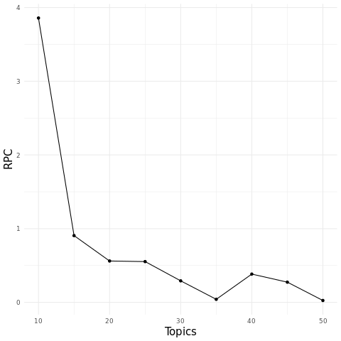

Elbow Plot

```r
LDAelbowPlot("output_directory", SeuratObj)
```

## Analyzing Models

Now that we have built a model and determine that it does a good job of capturing our data, we can analyze the model. For the rest of the vignette, we will be using a model with 20 topics that was built on a dataset containing T47D single cells, some treated with estrogen, some treated with progesterone, and some treated with both estrogen and progesterone.

### Input Data

First, read in the Seurat object RDS and the model RDS.

```r
SeuratObj <- readRDS("../data/PEPE_T47D.rds")
top_model <- readRDS("../data/Model_PEPE_T47D_20T_CLR_5000Variable_M10.rds")
```

The first step in the analysis pipeline is to add the topic information to the original Seurat object. This allows us to employ many of Seurat’s built in plot functions to visualize the model.

```r
SeuratObj <- addTopicsToSeuratObject(model = top_model, Object = SeuratObj)
```

### Gene-Topic Distribution

```r
GeneDistrubition <- GeneScores(top_model)

### head and sort the matrix by genes most contributing to Topic 1
head(GeneDistrubition[order(GeneDistrubition[,"Topic_1"], decreasing = T),], n = 10)
```

```
#>           Topic_1     Topic_2      Topic_3     Topic_4    Topic_5
#> AZGP1  0.13462648 0.000000000 9.824076e-06 0.000000000 0.00000000
#> FKBP5  0.13220745 0.000000000 0.000000e+00 0.000000000 0.00000000
#> S100P  0.11108734 0.000000000 0.000000e+00 0.000000000 0.00000000
#> FXYD3  0.08196128 0.000000000 0.000000e+00 0.000000000 0.00000000
#> HILPDA 0.07525380 0.000000000 0.000000e+00 0.000000000 0.03825168
#> AHNAK  0.07151233 0.005805519 0.000000e+00 0.015675503 0.00000000
#> GLUL   0.06954585 0.000000000 5.083990e-03 0.000000000 0.00000000
#> PIP    0.06203685 0.000000000 0.000000e+00 0.000000000 0.09790103
#> MRFAP1 0.05612389 0.001703317 0.000000e+00 0.009716846 0.00000000
#> FASN   0.05506104 0.000000000 0.000000e+00 0.000000000 0.02810035
#>              Topic_6      Topic_7     Topic_8     Topic_9 Topic_10
#> AZGP1   0.000000e+00 0.0000000000 0.000000000 0.000000000        0
#> FKBP5   0.000000e+00 0.0000000000 0.000000000 0.000000000        0
#> S100P   0.000000e+00 0.0000000000 0.000000000 0.000000000        0
#> FXYD3   0.000000e+00 0.0291734976 0.000000000 0.000000000        0
#> HILPDA  1.264409e-02 0.0000000000 0.000000000 0.000000000        0
#> AHNAK   1.480883e-02 0.0000000000 0.000000000 0.000000000        0
#> GLUL    0.000000e+00 0.0146496629 0.000000000 0.000000000        0
#> PIP     0.000000e+00 0.0000000000 0.000000000 0.000000000        0
#> MRFAP1  0.000000e+00 0.0002104898 0.000000000 0.009754049        0
#> FASN   -5.826328e-06 0.0000000000 0.005890966 0.000000000        0
#>        Topic_11 Topic_12    Topic_13    Topic_14 Topic_15 Topic_16
#> AZGP1         0        0 0.000000000 0.000000000        0        0
#> FKBP5         0        0 0.000000000 0.000000000        0        0
#> S100P         0        0 0.000000000 0.000000000        0        0
#> FXYD3         0        0 0.000000000 0.000000000        0        0
#> HILPDA        0        0 0.002902841 0.000000000        0        0
#> AHNAK         0        0 0.006582100 0.034600116        0        0
#> GLUL          0        0 0.006102321 0.002218462        0        0
#> PIP           0        0 0.000000000 0.000000000        0        0
#> MRFAP1        0        0 0.000000000 0.000000000        0        0
#> FASN          0        0 0.000000000 0.017114437        0        0
#>           Topic_17 Topic_18      Topic_19    Topic_20
#> AZGP1  0.000000000        0  0.000000e+00 0.000000000
#> FKBP5  0.000000000        0  0.000000e+00 0.000000000
#> S100P  0.000000000        0  0.000000e+00 0.000000000
#> FXYD3  0.000000000        0  0.000000e+00 0.000000000
#> HILPDA 0.000000000        0  0.000000e+00 0.000000000
#> AHNAK  0.001805462        0  0.000000e+00 0.003091371
#> GLUL   0.000000000        0  0.000000e+00 0.000000000
#> PIP    0.000000000        0  0.000000e+00 0.000137707
#> MRFAP1 0.006701468        0  0.000000e+00 0.008020512
#> FASN   0.000000000        0 -4.890298e-06 0.000000000
```

```r
TopicWords <- TopTopicGenes(top_model, ngenes = 50)
head(TopicWords, 10)
```

```
#>       Topic_1  Topic_2     Topic_3    Topic_4     Topic_5   Topic_6
#>  [1,] "AZGP1"  "DDIT3"     "CDK5RAP2" "RRS1"      "PIP"     "SLC40A1"
#>  [2,] "FKBP5"  "SAT1"      "PTMA"     "KRT18"     "ZG16B"   "CYP1B1"
#>  [3,] "S100P"  "JUND"      "HLTF"     "TP53I3"    "FBXO32"  "FOS"
#>  [4,] "FXYD3"  "ATF3"      "PRKDC"    "KRT8"      "HES1"    "HES1"
#>  [5,] "HILPDA" "SQSTM1"    "FGD5-AS1" "CLDN3"     "SELENOP" "SMARCA1"
#>  [6,] "AHNAK"  "TNFRSF12A" "HMGN2"    "ABCE1"     "S100A9"  "MT-ND4"
#>  [7,] "GLUL"   "HMGCS1"    "RANBP1"   "CLDN7"     "NUPR1"   "MYCBP2"
#>  [8,] "PIP"    "UBC"       "PSMC3"    "RPS2"      "DBI"     "TOB1"
#>  [9,] "MRFAP1" "MLF1"      "PCM1"     "RAB11FIP1" "IGFBP5"  "BTG1"
#> [10,] "FASN"   "DUSP14"    "EBP"      "FAM207A"   "RARRES3" "DBI"
#>       Topic_7  Topic_8     Topic_9  Topic_10  Topic_11 Topic_12
#>  [1,] "S100A9" "IDI1"      "TUBA1B" "ZFP36L2" "CENPF"  "PGP"
#>  [2,] "DEGS2"  "HNRNPA3"   "RAN"    "FOS"     "NUSAP1" "CENPX"
#>  [3,] "CCL28"  "HMGB1"     "SNRPB"  "ARL4D"   "PTTG1"  "NOP56"
```

[output cut: 29 more lines]

## Cell-Topic Distribution

The second distrubtion that TITAN outputs is the cell-topic distrubition which outputs the contribution each cell belongs to a topic, calculated from the gene scores. The `GetTopics` function outputs a scaled cell-topic matrix. Alternatively, the `addTopicsToSeuratObject` function added this cell-topic matrix to our metadata files so if that has been run it can also be done by wrangling the meta.data in your Seurat object.

```r
## Using the get topics function
LDA_topics <- GetTopics(top_model, SeuratObj)
head(LDA_topics)
```

```
#>                       Topic_1    Topic_2    Topic_3     Topic_4    Topic_5
#> AAACCCACACTGAATC_1  0.2579056 -0.6875578 -0.4952836  0.26333522  0.1477421
#> AAACCCATCTTTGCAT_1 -0.9389211  0.9302497 -0.6504646  0.06130594 -0.2794898
#> AAACGAACAAATGGTA_1 -0.4951609  0.8515864 -0.3061507  1.40620542 -1.1701668
#> AAACGAAGTGTCATGT_1 -0.9870433 -0.7481831  0.5260520 -0.18316540 -0.5311767
#> AAACGCTAGATTACCC_1 -0.6577751  0.2807817 -0.7965712  0.38200993  0.8697197
#> AAACGCTAGGCGTTGA_1 -0.4273528 -0.3371308 -0.6334652  1.51930067 -0.5124411
#>                       Topic_6    Topic_7     Topic_8     Topic_9
#> AAACCCACACTGAATC_1  1.7007007 -0.5366247  0.05039043  0.31967915
#> AAACCCATCTTTGCAT_1 -0.1817111 -0.1005293  0.27405077 -0.06139918
#> AAACGAACAAATGGTA_1 -0.6974080 -0.1807059 -0.31135215  0.54132837
#> AAACGAAGTGTCATGT_1 -0.1674966 -0.3774344 -0.33431588  0.66359537
#> AAACGCTAGATTACCC_1 -0.5858447  2.1458108  0.97934621 -0.56895199
#> AAACGCTAGGCGTTGA_1  0.4952923  0.5350512  1.73404204 -0.97403672
#>                      Topic_10   Topic_11    Topic_12    Topic_13
#> AAACCCACACTGAATC_1  0.3008185 -2.1955556 -0.19003573  0.13459673
#> AAACCCATCTTTGCAT_1 -0.1633737 -1.1978202 -0.49496973  0.26904684
#> AAACGAACAAATGGTA_1 -1.2092316 -1.0791592  0.99324546 -0.53236034
#> AAACGAAGTGTCATGT_1 -1.1992783 -0.1076491  0.61723706  0.04668229
#> AAACGCTAGATTACCC_1  1.1895278 -1.2417767 -0.07441461  1.12554695
#> AAACGCTAGGCGTTGA_1  0.7450958 -1.3802540 -0.64460641  1.91306600
#>                      Topic_14   Topic_15   Topic_16   Topic_17   Topic_18
#> AAACCCACACTGAATC_1 -0.4370345 -1.1569318  0.5217171  2.4942784 -1.1783644
#> AAACCCATCTTTGCAT_1 -0.2902747 -1.0645167  0.7554229 -0.4413251  3.5787286
#> AAACGAACAAATGGTA_1 -0.3786841 -0.5540989 -0.7831065  2.5794752  0.1159567
#> AAACGAAGTGTCATGT_1 -0.5592155  0.5975039 -0.4263256  3.5049417 -0.8929718
#> AAACGCTAGATTACCC_1 -1.1598774 -1.5927418  0.1226246 -1.0731378  0.3595397
#> AAACGCTAGGCGTTGA_1 -0.7307870 -1.6223023  1.1186540 -0.3495828 -0.2228788
#>                       Topic_19     Topic_20
#> AAACCCACACTGAATC_1  0.67993735  0.006286896
#> AAACCCATCTTTGCAT_1  0.16688581 -0.170895173
#> AAACGAACAAATGGTA_1  1.41754101 -0.207753439
#> AAACGAAGTGTCATGT_1 -0.05893455  0.617178158
#> AAACGCTAGATTACCC_1 -0.64870367  0.944887586
#> AAACGCTAGGCGTTGA_1  0.10403925 -0.329703373
```

```r
## Using the meta data columns (must run addTopicsToSeruatObject() first)
library(tidyverse)
LDA_topics <- SeuratObj@meta.data %>% select(starts_with("Topic"))
head(LDA_topics)
```

```
#>                       Topic_1    Topic_2    Topic_3     Topic_4    Topic_5
#> AAACCCACACTGAATC_1  0.2579056 -0.6875578 -0.4952836  0.26333522  0.1477421
#> AAACCCATCTTTGCAT_1 -0.9389211  0.9302497 -0.6504646  0.06130594 -0.2794898
#> AAACGAACAAATGGTA_1 -0.4951609  0.8515864 -0.3061507  1.40620542 -1.1701668
#> AAACGAAGTGTCATGT_1 -0.9870433 -0.7481831  0.5260520 -0.18316540 -0.5311767
#> AAACGCTAGATTACCC_1 -0.6577751  0.2807817 -0.7965712  0.38200993  0.8697197
#> AAACGCTAGGCGTTGA_1 -0.4273528 -0.3371308 -0.6334652  1.51930067 -0.5124411
#>                       Topic_6    Topic_7     Topic_8     Topic_9
#> AAACCCACACTGAATC_1  1.7007007 -0.5366247  0.05039043  0.31967915
#> AAACCCATCTTTGCAT_1 -0.1817111 -0.1005293  0.27405077 -0.06139918
#> AAACGAACAAATGGTA_1 -0.6974080 -0.1807059 -0.31135215  0.54132837
#> AAACGAAGTGTCATGT_1 -0.1674966 -0.3774344 -0.33431588  0.66359537
#> AAACGCTAGATTACCC_1 -0.5858447  2.1458108  0.97934621 -0.56895199
#> AAACGCTAGGCGTTGA_1  0.4952923  0.5350512  1.73404204 -0.97403672
#>                      Topic_10   Topic_11    Topic_12    Topic_13
#> AAACCCACACTGAATC_1  0.3008185 -2.1955556 -0.19003573  0.13459673
#> AAACCCATCTTTGCAT_1 -0.1633737 -1.1978202 -0.49496973  0.26904684
#> AAACGAACAAATGGTA_1 -1.2092316 -1.0791592  0.99324546 -0.53236034
#> AAACGAAGTGTCATGT_1 -1.1992783 -0.1076491  0.61723706  0.04668229
#> AAACGCTAGATTACCC_1  1.1895278 -1.2417767 -0.07441461  1.12554695
#> AAACGCTAGGCGTTGA_1  0.7450958 -1.3802540 -0.64460641  1.91306600
#>                      Topic_14   Topic_15   Topic_16   Topic_17   Topic_18
#> AAACCCACACTGAATC_1 -0.4370345 -1.1569318  0.5217171  2.4942784 -1.1783644
#> AAACCCATCTTTGCAT_1 -0.2902747 -1.0645167  0.7554229 -0.4413251  3.5787286
#> AAACGAACAAATGGTA_1 -0.3786841 -0.5540989 -0.7831065  2.5794752  0.1159567
#> AAACGAAGTGTCATGT_1 -0.5592155  0.5975039 -0.4263256  3.5049417 -0.8929718
#> AAACGCTAGATTACCC_1 -1.1598774 -1.5927418  0.1226246 -1.0731378  0.3595397
#> AAACGCTAGGCGTTGA_1 -0.7307870 -1.6223023  1.1186540 -0.3495828 -0.2228788
#>                       Topic_19     Topic_20
#> AAACCCACACTGAATC_1  0.67993735  0.006286896
#> AAACCCATCTTTGCAT_1  0.16688581 -0.170895173
#> AAACGAACAAATGGTA_1  1.41754101 -0.207753439
#> AAACGAAGTGTCATGT_1 -0.05893455  0.617178158
#> AAACGCTAGATTACCC_1 -0.64870367  0.944887586
#> AAACGCTAGGCGTTGA_1  0.10403925 -0.329703373
```

## Heatmap

Although, the cell-topic matrix contains valuable infomration about each cells contribution to each topic. It is often hard to parse. For this reason, it is nice to visualize which cells contribute to each topic and how each topic compares to eachother.To do this, we recommend visualizing the cell-topic matrix in heatmap form. The goal is to see which cells express which topics. The `heatmap` function allows one to plot the topics across a heatmap and sort the cells by a column of interest. In our case, we are wondering whihch topics are associated with each treatment so we will be annotating the function with our treatment column, but one could use any other metadata column

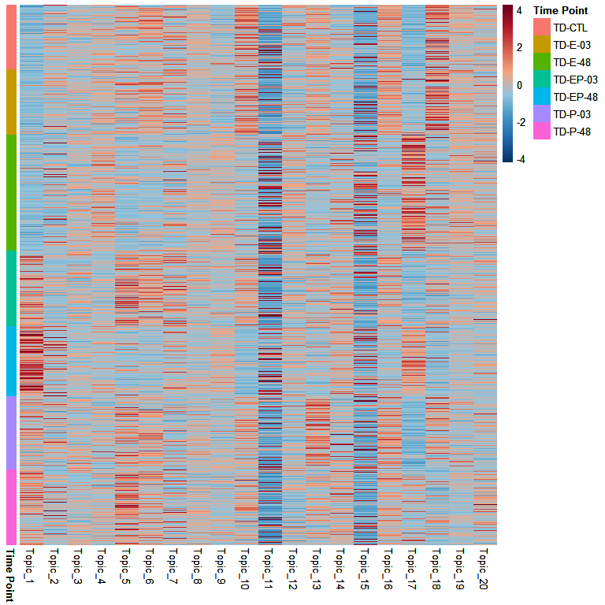

```r
HeatmapTopic(Object = SeuratObj,
        topics =  LDA_topics,
        AnnoVector = SeuratObj@meta.data$hash.ID,
        AnnoName = "Time Point")
```

You can also cluster the topics of the heatmap so that topics with similar expression patterns across cells are grouped together.

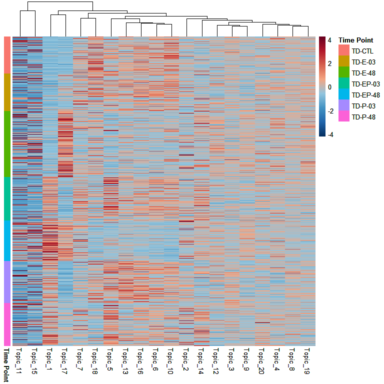

```r
HeatmapTopic(Object = SeuratObj,
             topics =  LDA_topics,
             AnnoVector = SeuratObj@meta.data$hash.ID,
             AnnoName = "Time Point",
             clusterTopics = T)
```

In both of the above cases, the rows of the heatmap were sorted by time point. They can be sorted by any metadata column in the Seurat object as well, such as cluster.

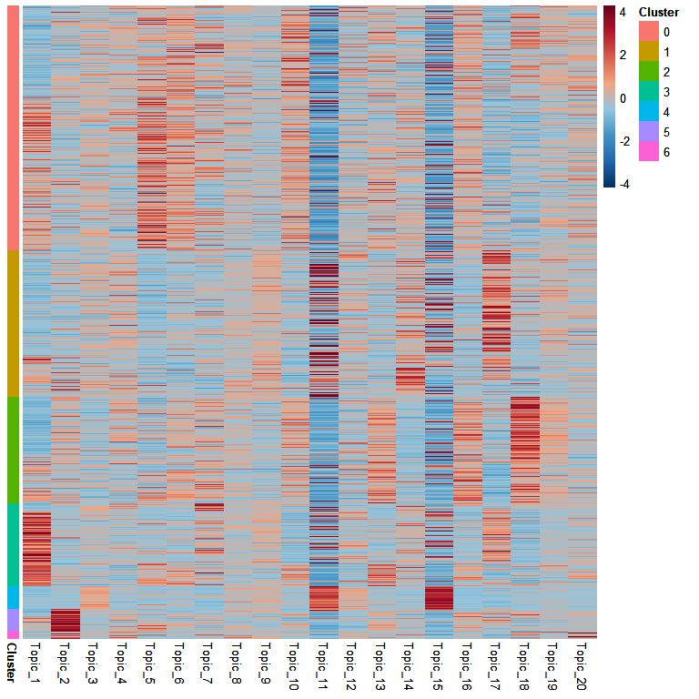

```r
HeatmapTopic(Object = SeuratObj,
             topics =   LDA_topics,
             AnnoVector = SeuratObj$seurat_clusters,
             AnnoName = "Cluster")
```

## On UMAP

Another way to visualize the expression of the topics is through Seurat’s FeaturePlot function. This plots the cells using the UMAP embeddings within the Seurat object, and then colors the cells based on their expression of the given topic.

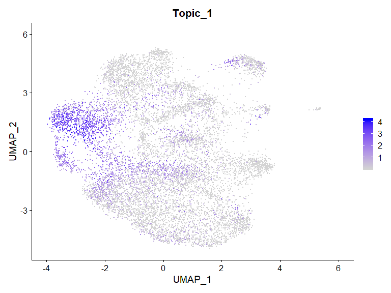

```r
FeaturePlot(SeuratObj,
            pt.size = 0.01,
            features  = "Topic_1",
            min.cutoff = 'q1')
```

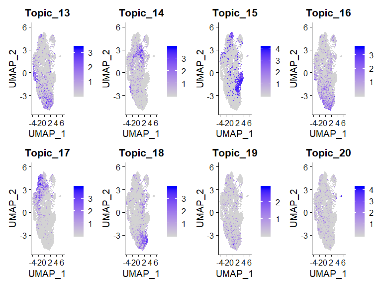

```r
FeaturePlot(SeuratObj,
            pt.size = 0.01,
            features  = paste("Topic", 13:20, sep = "_"),
            ncol = 4,
            min.cutoff = 'q1')
```

## Plotting two LDA topics against eachother

Further, we find it also useful to plot two LDA topics against eachother when trying to compare how cells react to different tracriptional topics. An example being in our T47D expriment, we were interested in how the progestorne-specific topic (Topic 1) and an estrogen-specific topic (Topic 17) segregate out cells by treatment. To do this, we can plot the scores of the two topics using the `DimPlot` function in Seurat. When running `addTopicsToSeruatObject`, the function creates a DimReducObject under the name “lda” which can be used to plot the two against eachother.

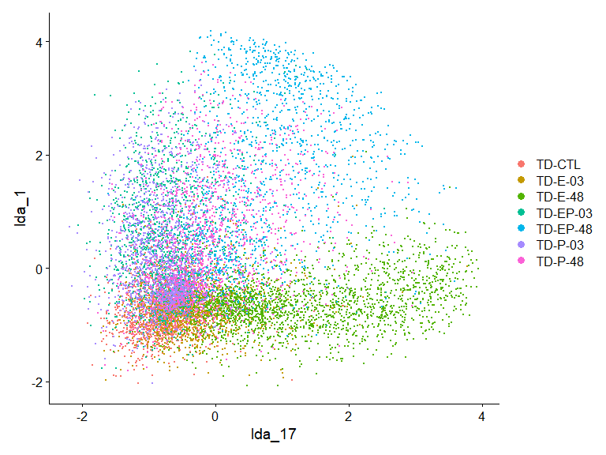

```r
DimPlot(SeuratObj,
        pt.size = 0.01,
        reduction = "lda",
        dims = c(17,1),
        group.by = "hash.ID")
```

Further, if one wanted to visualize the expression of a gene across two topic gradients one could also utalize the `FeaturePlot` function using the “lda” reduction as shown below.

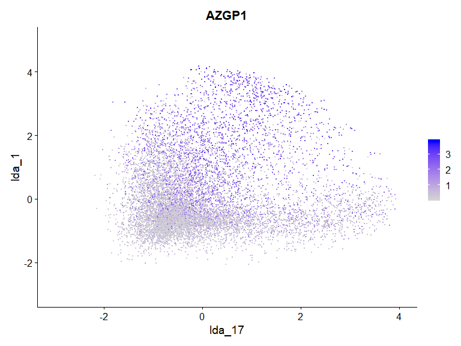

```r
FeaturePlot(SeuratObj,
        pt.size = 0.01,
        reduction = "lda",
        dims = c(17,1),
        features = "AZGP1",
        min.cutoff = 'q1')
```

Another example of how one could look at the data would be to see how two topics that have similar patterns differ from eachother. If one looks back at the heatmap, topics 11 and topics 17 both showed high expression at the late estrogen timepoint, yet when ploted against eachother one can see a start pattern of cells that either undergo one topic or the other, but uncommon for both topics to be high in the same cell.

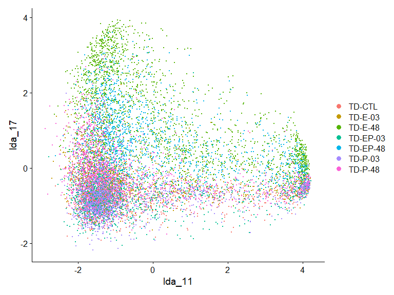

```r
DimPlot(SeuratObj,
        pt.size = 0.01,
        reduction = "lda",
        dims = c(11,17),
        group.by = "hash.ID")
```